# Developmental Relationships CFAs 2

Author

Landon Cox

# Background

**NoteMeasure Description**

The **Developmental Relationships (DR) 360** Search Institute (2021) is an 8-item measure designed to assess the quality of developmental relationships and the resources individuals receive through those relationships. Developmental relationships are close connections through which young people discover who they are, develop the ability to shape their lives, and learn how to interact with and contribute to the world around them.

Subscales:

- **Elements of a Developmental Relationship**: assesses whether relational partners express care, challenge growth, provide support, share power, and expand possibilities.
- **Resources Acquired From Relationships**: asseseses access to useful information, skill-building opportunities, and connections to other people who can support educational or career goals.

The DR 360 is intended to provide a snapshot of an individual’s relational web and can be used across different relational targets, such as peers, teachers, and mentors.

**NoteItems**

| Item Name | Item Text | Subscale |
| --- | --- | --- |
|  | These questions are about your most important mentor. This mentor… |  |
| `dr01` | …shows me that I matter to him/her. | Elements of a Developmental Relationship |
| `dr02` | …challenges me to be my best. | Elements of a Developmental Relationship |
| `dr03` | …listens to my ideas and takes them seriously. | Elements of a Developmental Relationship |
| `dr04` | …helps me accomplish tasks. | Elements of a Developmental Relationship |
| `dr05` | …introduces me to new experiences or opportunities. | Elements of a Developmental Relationship |
| `dr06` | …provides me with useful information for pursuing my education or career goals. | Resources Acquired from Relationships |
| `dr07` | …supports me in developing or strengthening the skills needed to pursue my education or career goals. | Resources Acquired from Relationships |
| `dr08` | …connects me with other people who help me pursue my education or career goals | Resources Acquired from Relationships |

# Data Preparation

## Import Data

```r
# Data import
dat <- read.csv("00_raw_data/data_help-seeking.csv") # Reads and stores original data

# Create data frame with only variables of interest
dat_vars <- dat |>
  dplyr::select(starts_with("dr"))
```

## Rename Variables

```r
# Rename the columns
dat_vars <-
  dat_vars |>
  rename(
    dr01 = dr1_developmentalrelationships1_elements1,
    dr02 = dr2_developmentalrelationships2_elements2,
    dr03 = dr3_developmentalrelationships3_elements3,
    dr04 = dr4_developmentalrelationships4_elements4,
    dr05 = dr5_developmentalrelationships5_elements5,
    dr06 = dr6_developmentalrelationships6_resources.aquired1,
    dr07 = dr7_developmentalrelationships7_resources.acquired2,
    dr08 = dr8_developmentalrelationships8_resources.acquired3)
```

## Rescale Variables

```r
# Check data (Generates a stats summary for newly renamed variables)
varNames <- grep("dr", names(dat_vars), value = TRUE)
summary(dat_vars[,varNames])

# Loop the POM function over all columns of data
for (i in 1:length(varNames)) {
  dat_vars[,varNames[i]] <- POM_fixed(x = dat_vars[,varNames[i]],
                                      min_x = 0,
                                      max_x = 100)*5
}
```

# CFAs

## Model A

**NoteModel Specifications**

- **Type**: One-factor
- **Indicators**: 8
- **Modifications**: None

### Factor Specification

```r
## Developmental Relationships A (One Factor)
dev_relA <- '
# Define the latent factors.
dev_rel =~ dr01 +
           dr02 +
           dr03 +
           dr04 +
           dr05 +
           dr06 +
           dr07 +
           dr08
'
```

### Measurement Model Results

**Fit**

Model Fit Indices

| Measure | Value |
| --- | --- |
| χ² | 77.037 |
| df | 20.000 |
| p | 0.000 |
| CFI | 0.918 |
| TLI | 0.886 |
| RMSEA | 0.161 |
| SRMR | 0.062 |

**Loadings**

Factor Loadings

|  |  |  | Coeff | SE | 95% CI | z | p |
| --- | --- | --- | --- | --- | --- | --- | --- |
| dev_rel | =~ | dr01 | 0.861 | 0.028 | 0.806,0.916 | 30.721 | 0 |
| dev_rel | =~ | dr02 | 0.890 | 0.023 | 0.845,0.936 | 38.192 | 0 |
| dev_rel | =~ | dr03 | 0.881 | 0.025 | 0.832,0.93 | 35.258 | 0 |
| dev_rel | =~ | dr04 | 0.735 | 0.047 | 0.643,0.827 | 15.659 | 0 |
| dev_rel | =~ | dr05 | 0.754 | 0.044 | 0.668,0.841 | 17.116 | 0 |
| dev_rel | =~ | dr06 | 0.794 | 0.039 | 0.718,0.869 | 20.592 | 0 |
| dev_rel | =~ | dr07 | 0.902 | 0.022 | 0.86,0.944 | 41.860 | 0 |
| dev_rel | =~ | dr08 | 0.429 | 0.081 | 0.269,0.588 | 5.269 | 0 |

**Plot**

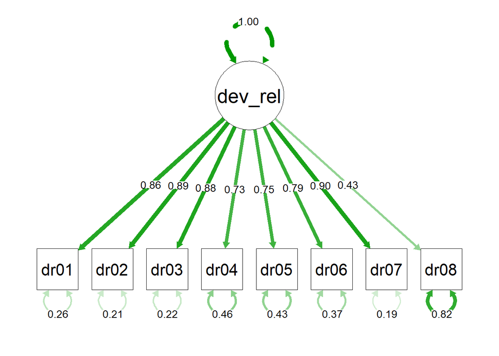

## Model D

**NoteModel Specifications**

- **Type**: One-factor
- **Indicators**: 7
- **Modifications**: Remove `dr08`

### Factor Specifications

```r
## Developmental Relationships D (One Factor remove 'dr08')
dev_relD <- '
# Define the latent factors.
dev_rel =~ dr01 +
           dr02 +
           dr03 +
           dr04 +
           dr05 +
           dr06 +
           dr07
'
```

### Measurement Model Results

**Fit**

Model Fit Indices

| Measure | Value |
| --- | --- |
| χ² | 23.531 |
| df | 14.000 |
| p | 0.052 |
| CFI | 0.985 |
| TLI | 0.977 |
| RMSEA | 0.079 |
| SRMR | 0.025 |

**Loadings**

Factor Loadings

|  |  |  | Coeff | SE | 95% CI | z | p |
| --- | --- | --- | --- | --- | --- | --- | --- |
| dev_rel | =~ | dr01 | 0.868 | 0.027 | 0.816,0.921 | 32.476 | 0 |
| dev_rel | =~ | dr02 | 0.894 | 0.023 | 0.85,0.939 | 39.465 | 0 |
| dev_rel | =~ | dr03 | 0.882 | 0.025 | 0.833,0.931 | 35.635 | 0 |
| dev_rel | =~ | dr04 | 0.732 | 0.047 | 0.639,0.825 | 15.447 | 0 |
| dev_rel | =~ | dr05 | 0.746 | 0.045 | 0.657,0.834 | 16.481 | 0 |
| dev_rel | =~ | dr06 | 0.785 | 0.040 | 0.706,0.863 | 19.696 | 0 |
| dev_rel | =~ | dr07 | 0.901 | 0.022 | 0.859,0.944 | 41.453 | 0 |

**Plot**

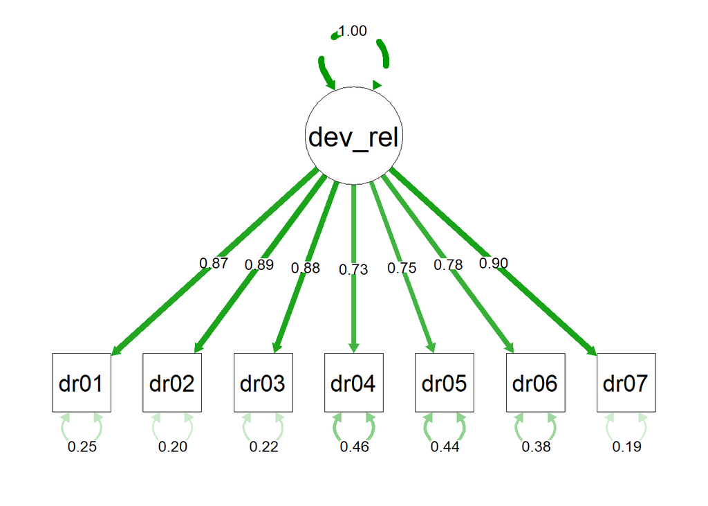

## Model F

**NoteModel Specifications**

- **Type**: One-factor
- **Indicators**: 3
- **Modifications**: Balanced parcels with `dr08` removed

### Parceling

```r
## Developmental Relationships PB (Balanced Parceling, removed dr08)
# Create parcels using the Balancing Technique
dat_vars$drPB1 <- rowMeans(dat_vars[c("dr07",
                                      "dr04")],
                                na.rm = TRUE)

dat_vars$drPB2 <- rowMeans(dat_vars[c("dr02",
                                      "dr05")],
                                na.rm = TRUE)

dat_vars$drPB3 <- rowMeans(dat_vars[c("dr03",
                                      "dr01",
                                      "dr06")],
                                na.rm = TRUE)
```

### Factor Specification

```r
dev_relF <- '
# Define the latent factors.
dev_rel =~ drPB1 +
           drPB2 +
           drPB3
'
```

### Measurement Model Results

**Fit**

Model Fit Indices

| Measure | Value |
| --- | --- |
| χ² | 0 |
| df | 0 |
| p | NA |
| CFI | 1 |
| TLI | 1 |
| RMSEA | 0 |
| SRMR | 0 |

**Loadings**

Factor Loadings

|  |  |  | Coeff | SE | 95% CI | z | p |
| --- | --- | --- | --- | --- | --- | --- | --- |
| dev_rel | =~ | drPB1 | 0.904 | 0.023 | 0.859,0.949 | 39.579 | 0 |
| dev_rel | =~ | drPB2 | 0.898 | 0.024 | 0.852,0.944 | 38.116 | 0 |
| dev_rel | =~ | drPB3 | 0.938 | 0.019 | 0.9,0.975 | 48.957 | 0 |

**Plot**

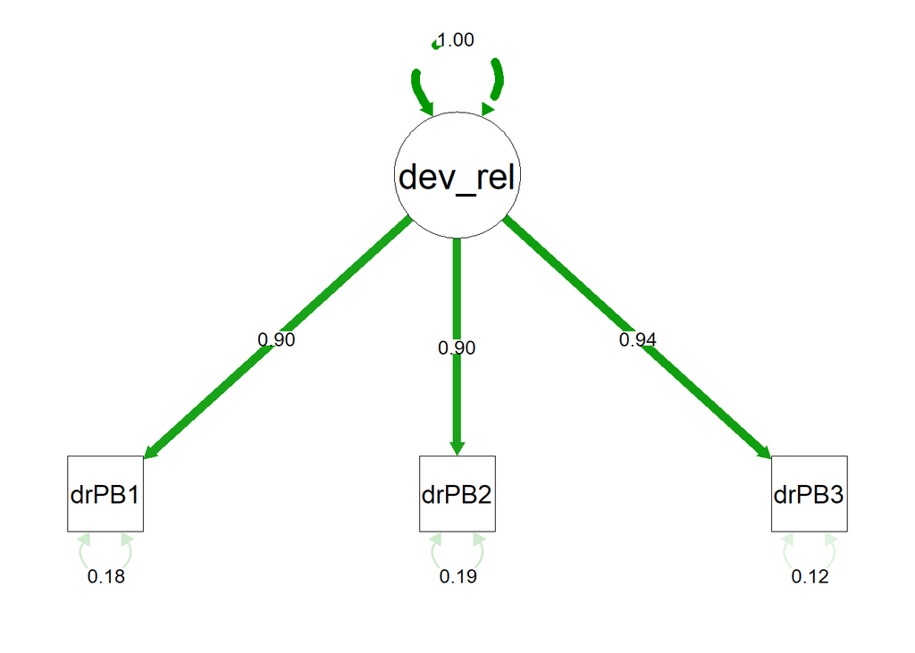

## Fit Table

*Figure 1 – Fit Table*

| Model | χ2 | df | χ2∕df | p | CFI | TLI | RMSEA [90% CI] | SRMR | AIC | BIC |
| --- | --- | --- | --- | --- | --- | --- | --- | --- | --- | --- |
| Model A | 77.04 | 20 | 3.85 | < .001 | .92 | .89 | .16 [.12, .20] | .06 | 1,961.17 | 2,025.98 |
| Model D | 23.53 | 14 | 1.68 | .052 | .98 | .98 | .08 [.00, .13] | .02 | 1,591.27 | 1,647.98 |
| Model F | 0.00 | 0 | Inf |  | 1.0 | 1.0 | .00 [.00, .00] | .00 | 607.72 | 632.03 |
| Common guidelinesa | — | — | < 2 or 3 | > .05 | ≥ .95 | ≥ .95 | < .05 [.00, .08] | ≤ .08 | Smaller | Smaller |

aBased on Schreiber (2017), Table 3.

# Conclusion

Item `dr08` was removed in the **Developmental Relationships D** model due to distinctly poor loading in all models. This change improved fit to acceptable levels as shown in the fit table (Figure 1).

Researchers intending to use the this measure are advised to use it as a unidimensional model and consider removing the 8th item, `dr08`.

## References

Search Institute. 2021. *Social Capital Assessment and Learning for Equity (SCALE) Measures: User Guide*. Minneapolis, MN.